# Introdução ao R para Data Science

Alan Rodrigo Panosso alan.panosso@unesp.br

25/11/2020

[figure not shown]

# 1. Material Base do Curso

Textos podem ser encontrados gratuitamente online!

[figure not shown]

Long, J. D. & Teetor, P. (2019) R Cookbook. USA: O’Reilly Media, Inc, https://rc2e.com/.

[figure not shown]

Wickham, H. & Grolemund G. (2019) R for Data Science. https://r4ds.had.co.nz/.

# 2. Ciência dos Dados (Data Science)

É uma área interdisciplinar voltada para o estudo e a análise de dados, estruturados e não-estruturados, que visa a extração de conhecimento, detecção de padrões e/ou obtenção de variáveis para possíveis tomadas de decisão. O modelo base das ferramentas necessárias em um projeto típico de ciência dos dados é parecido com isso:

**Importar os dados:** Sem eles no R, não conseguimos fazer nada…

**Organizar os dados:** De forma consistente que combine a semântica da base de dados com a maneira em que são armazenados.

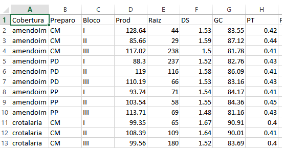

Exemplo de dados organizados em uma planilha eletrônica, onde cada coluna é uma variável e cada linha é uma observação.

**Transformar os dados:** Literalmente, recortar o banco de dados, assim podemos focar nas observações de interesse. Criar novas variáveis em função das existentes e calcular, por exemplo, um resumo estatístico desse conjunto de interesse.

Agora podemos gerar o conhecimento, através da **Visualização** e **Modelagem**.

[figure not shown]

**Comunicação**: É a última etapa do data science, a mais importante.

Uma dica importante, estudar um pouco de **RMarkdown**! Ótima linguagem de marcação de texto, utilizada para gerar relatórios em HTML, .doc e pdf.

[figure not shown]

https://bookdown.org/yihui/rmarkdown-cookbook/

# 3. Motivação

**PROGRAMAÇÃO:** Permeia todas as etapas da Ciência dos Dados.

Uma questão recursiva…

O computador é a ferramenta do cientista de dados.

R é um ambiente e linguagem de programação de código aberto para computação estatística, bioinformática e gráficos.

- Como linguagem de programação, garante a reprodutibilidade das análises.
  - Estudantes podem usar as mesmas ferramentas que os profissionais.
  - Todos podem usar as melhores ferramentas independente do poder financeiro.
  - Qualquer um pode reproduzir as suas análises.
  - Você pode corrigir problemas.
  - Você pode desenvolver suas próprias ferramentas.
- Linguagem orientada a objetos R (Ross Ihaka e Robert Gentleman).
- R é uma poderosa linguagem, flexível e possui excelentes facilidades gráficas.
- R é um projeto **open-source** e está disponível na internet sobre a General Public License (<www.gnu.org/copyleft/gpl.html> e <www.fsf.org>).

# 4. Ambientação

### 4.1. Instalando o R

Baixe o R do site oficial The R Project for Statistical Computing https://www.r-project.org/

Acesso rápido: [Download](https://cran-r.c3sl.ufpr.br/bin/windows/base/R-4.0.3-win.exe)

Salve o arquivo de instalação em um diretório de seu computador e em seguida execute-o.

O processo é simples e intuitivo.

### 4.2. Instalando o RStudio

É um ambiente de desenvolvimento integrado (IDE) para o R, disponível em https://rstudio.com/products/rstudio/download/

Escolha a o instalador de acordo com o seu sistema operacional. **Windows** no nosso caso.

Novamente, salve o arquivo de instalação em um diretório de seu computador e em seguida execute-o.

Após a instalação procure o ícone do R criado pelo instalador e clique nele.

# 5. Pacotes no R (instalação dos pacotes)

Um pacote é uma coleção de funções, exemplos e documentação. A funcionalidade de um pacote é frequentemente focada em uma metodologia estatística especial" (**Everitt & Hothorn**).

[figure not shown]

Liste os pacotes carregados no ambiente com:

```r
(.packages())
```

```
## [1] "stats"     "graphics"  "grDevices" "utils"     "datasets"  "methods"
## [7] "base"
```

Carregue um pacote, utilize a função `library`.

```r
library(tidyverse)
```

Agora, liste novamente os pacotes e observe a diferença no retorno da função.

```r
(.packages())
```

```
##  [1] "forcats"   "stringr"   "dplyr"     "purrr"     "readr"     "tidyr"
##  [7] "tibble"    "ggplot2"   "tidyverse" "stats"     "graphics"  "grDevices"
## [13] "utils"     "datasets"  "methods"   "base"
```

**Utilizando a opção** `Install/Packages`

Instale alguns pacotes:

- `tidyverse`
- `agricolae`
- `readxl`
- `stringr`
- `lubridate`

# 6. Operações Básicas

### 6.1. Operação aritmética

```r
1 + 7
1 - 2 * 10
2 ** 10
10/3
```

### 6.2. Algumas funções matemáticas e trigonométricas

$$\begin{aligned}
& a)\;\sqrt{9} = 3\\
& b)\;seno\;\pi = 0\\
& c)\;4! = 24\\
& d)\; e^5 = 148,4132
\end{aligned}$$

```r
sqrt(9)
sin(pi)
factorial(4)
exp(5)
```

### 6.3. Operações Relacionais

$$\begin{aligned}
& a)\;7 > 5 \text{ retorna 'verdadeiro'}\\
& b)\;8 \leq 4 \text{ retorna 'falso'}\\
& c)\;5 = \frac{25}{5} \text{ retorna 'verdadeiro'}\\
& d)\; 4\neq 8 \text{ retorna 'verdadeiro'}
\end{aligned}$$

```r
7 > 5 ; 4 != 8
```

```
## [1] TRUE
```

```
## [1] TRUE
```

```r
nome <- 'Alan'
nome == 'Rodrigo'
```

```
## [1] FALSE
```

```r
nome == "Alan"
```

```
## [1] TRUE
```

### 6.4. Operações Lógicas

$$\begin{aligned}
& a)\;7 > 5 \; OU \; 8 \leq 4 \text{ retorna 'verdadeiro'}\\
& b)\;5 = \frac{25}{5} \; E \; 4 > 8 \text{ retorna 'falso'} \\
& c) \text{ Não} \; \text{TRUE}\; \text{retorna 'falso'} \\
& d) \text{ Não} \; \text{FALSE} \; \text{retorna 'verdadeiro'}
\end{aligned}$$

```r
7 > 5 | 8 <= 4
5 == 25/5 & 4 > 8
!TRUE
!FALSE

x <- c(1, 4, 2, NA, 8)
is.na(x)
x[!is.na(x)]
```

# 7. O R como uma calculadora

Resolva as seguintes expressões:
$$\begin{aligned}
& a)\; log\;3 \\
& b)\; ln\;10\\
& c)\; e^{2,302585}\\
& d)\; \sqrt(225)\\
& e)\; 5!\\
& f)\; seno\;30°\\
\end{aligned}$$

```r
log10(3)
log(10)
round( exp(2.302585) )
sqrt(225)
factorial(5)
sin(30*pi/180)
```

# 8. Tipos de dados, atribuição e principais objetos no R

### 8.1. Tipos de dados

Principais tipos de dados no R, como o computador interpreta a informação.

```r
# Caracter
letters
LETTERS
'Aluno'
"1235"

# Inteiro
1235
-4

# Double (ponto flutuante)
3.14
1/8
sqrt(7)

# Lógico
TRUE
FALSE
```

### 8.2. Atribuição

Símbolo utilizado para guardar uma informação em um objeto no R.

```r
x <- pi
y <- -5:5
nome <- "Cartola"
res  = (nome == "Alan")
x <- 4 # atribuição tem caráter destrutivo, ele sobrescreve a informação
X <- pi
```

### 8.3. Objetos

#### Escalar

É um objeto ao qual é atribuído um valor que pode ter qualquer um dos tipos.

```r
x <- 10
"Maria" -> nome # Não muito utilizado
```

Quando uma estrutura de dados é composta de variáveis com o mesmo tipo primitivo, temos um conjunto de dados homogêneo (vetores, fatores e matrizes).

#### Vetor

É considerada a **forma mais simples de armazenamento de dados** em um objeto, são classificados como variáveis com **um ou mais valores do mesmo tipo**. Na verdade, um escalar para o R é definido como um vetor com um único elemento. Essa estrutura de dados tem o 1 como índice inicial. E podem ser referenciados por **[k]** onde k é a posição do elemento no vetor.

```r
# Criando um vetor e acessando um valor
z<-c(3,2,7,4,5)
z[3]
```

```
## [1] 7
```

```r
# Criando sequências
x <- 1:100
sequencia <- seq(0,100,12)
vetor <- rep(1,10)
test <- rep("testemunha",4)

# Obtendo informações de objetos
is.vector(x)
```

```
## [1] TRUE
```

```r
is.vector(z)
```

```
## [1] TRUE
```

```r
length(x)
```

```
## [1] 100
```

```r
# Uma matriz, tem a dimensão de linha de coluna
A <- matrix(c(1,2,3,4,5,6,7,8,0), byrow = FALSE, ncol=3)
A
```

```
##      [,1] [,2] [,3]
## [1,]    1    4    7
## [2,]    2    5    8
## [3,]    3    6    0
```

```r
det(A)
```

```
## [1] 27
```

```r
solve(A)
```

```
##            [,1]       [,2]       [,3]
## [1,] -1.7777778  1.5555556 -0.1111111
## [2,]  0.8888889 -0.7777778  0.2222222
## [3,] -0.1111111  0.2222222 -0.1111111
```

```r
round(A %*% solve(A))
```

```
##      [,1] [,2] [,3]
## [1,]    1    0    0
## [2,]    0    1    0
## [3,]    0    0    1
```

```r
(A %*% solve(A)) %*% A
```

```
##      [,1] [,2] [,3]
## [1,]    1    4    7
## [2,]    2    5    8
## [3,]    3    6    0
```

Um conjunto heterogêneo de dados é composto por elementos que não são do mesmo tipo primitivo, como exemplo, temos os data.frames e as listas (ou registros).

#### Data Frames

Os data.frames são considerados a **melhor forma de armazenar dados**, pois cada linha corresponde a uma observação e cada coluna representa uma medida realizada em cada unidade (característica ou variável).

```r
# Criando vetores
RA <- c(1933456,1935432,1869524)
Nome <- c("Maria Eduarda Ferreira","Paulo Antunes Arantes","Ricardo Luís Siqueira")
Média <- c(9.5,7.75,4.8)
Situação <- c("Aprovado","Aprovado","Exame")

# Criando o data.frame
NOTAS <- data.frame(RA, Nome, Média,Situação)

# Obtendo Informações
length(NOTAS)
```

```
## [1] 4
```

```r
length(RA)
```

```
## [1] 3
```

```r
dim(NOTAS)
```

```
## [1] 3 4
```

```r
nrow(NOTAS)
```

```
## [1] 3
```

```r
NOTAS[c(1,3),3:4]
```

```
##   Média Situação
## 1   9.5 Aprovado
## 3   4.8    Exame
```

# 9. Entrada de dados

### 9.1. Lendo diretamente da internet

Acesse o GitHub do Professor https://github.com/arpanosso/cursoR_conbea_2020

```r
dados <- read.table("https://raw.githubusercontent.com/arpanosso/cursoR_conbea_2020/main/dados/geomorfologia.txt",
                    h=TRUE,
                    sep="\t")
```

### 9.2. Banco de dados em TXT

Faça o download do banco de dados geomorfologia.txt

```r
dados <- read.table("C:/R/geomorfologia.txt",h=TRUE,sep="\t")
```

### 9.3. Dados do Excel

Faça o download do banco de dados geomorfologia.xlsx

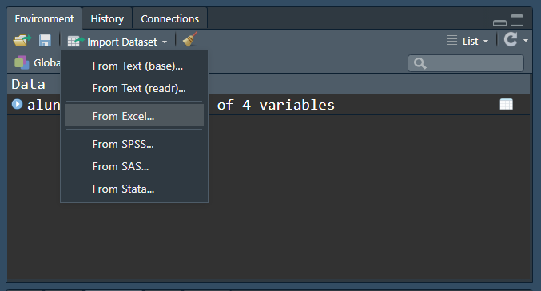

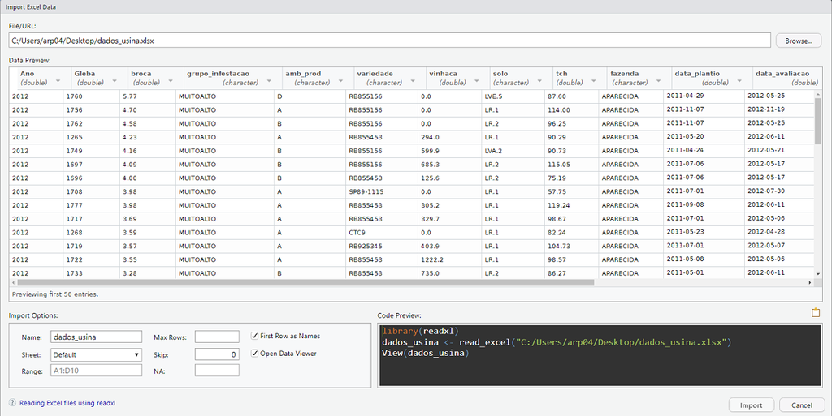

```r
library(readxl)
# geomorfologia <- read_excel("C:/Users/Panosso/Desktop/geomorfologia.xlsx")
# View(geomorfologia)
```

# 10. Manipulação dos dados

Para a manipulação dos nossos dados, vamos utilizar o pacote `dplyr`, que é um pacote específico para a manipulação de dados, unido ao pacote `ggplot2` é um poderoso recurso para exploração, transformação e visualização de dados. Ambos os pacotes fazem parte do `tidyverse`, que, como já dito, é um pacote de pacotes.

#### 10.1. Principais funções (verbos) do `dplyr`.

- `filter()`: seleciona/filtra por linhas (observações) a base de dados
- `arrange()`: ordena a base de dados de acordo com alguma coluna (variável)
- `select()`: seleciona colunas (variáveis)
- `mutate()`: modifica/transforma/cria variáveis (colunas)
- `summarise()`: resume/agrega, variáveis (colunas) de uma base de dados

#### 10.2. Regras para manipulação:

1- O primeiro argumento sempre será um `data.frame`.  
2- Demais argumentos, descrevem como deve ser a manipulação.  
3- A resposta sempre será um `data.frame`.  
4- Manipulação é realizada com o operador “PIPE” (`%>%`) - `CTRL SHIFT + M`.

#### 10.3. glimpse

A função `glimpse` retorna uma visão rápida a respeito da base de dados.

```r
glimpse(dados)
```

```
## Rows: 106
## Columns: 22
## $ SUP     <chr> "I", "I", "I", "I", "I", "I", "I", "I", "I", "I", "I", "I",...
## $ Solo    <chr> "LV", "LV", "LV", "LV", "LV", "LV", "LV", "LV", "LV", "LV",...
## $ Amostra <int> 1, 2, 3, 4, 5, 6, 7, 8, 9, 10, 11, 12, 13, 14, 15, 16, 17, ...
## $ X       <int> 0, 25, 50, 75, 100, 125, 150, 175, 200, 225, 250, 275, 300,...
## $ AMG     <dbl> 0.2, 0.1, 0.7, 0.4, 0.4, 0.4, 1.2, 0.8, 1.1, 1.2, 0.1, 0.2,...
## $ AG      <dbl> 3.72, 4.27, 5.00, 3.80, 3.10, 3.80, 3.60, 4.70, 4.50, 5.90,...
## $ AM      <dbl> 20.4, 22.6, 22.7, 23.7, 22.3, 23.8, 23.1, 25.8, 25.5, 32.8,...
## $ AF      <dbl> 22.9, 23.6, 22.2, 24.4, 24.6, 19.1, 21.7, 21.1, 18.9, 19.8,...
## $ AMF     <dbl> 30.0, 28.4, 26.9, 26.7, 26.9, 27.1, 26.5, 24.7, 25.4, 21.7,...
## $ SILTE   <dbl> 1.2, 1.2, 1.2, 0.6, 2.1, 2.2, 0.7, 0.2, 2.5, 0.2, 2.5, 2.6,...
## $ ARGILA  <dbl> 21.5, 20.4, 21.4, 20.5, 20.7, 23.5, 23.1, 22.7, 22.0, 18.5,...
## $ S_A     <dbl> 0.05, 0.05, 0.05, 0.02, 0.10, 0.09, 0.03, 0.01, 0.11, 0.01,...
## $ AF_AG   <dbl> 6.16, 5.53, 4.44, 6.42, 7.94, 5.03, 6.03, 4.49, 4.20, 3.36,...
## $ P       <int> 42, 22, 41, 27, 11, 12, 11, 16, 38, 25, 25, 6, 6, 7, 5, 4, ...
## $ pH      <dbl> 4.2, 3.8, 4.8, 4.0, 4.4, 4.0, 4.8, 5.4, 4.4, 5.2, 4.5, 5.1,...
## $ K       <dbl> 0.27, 0.11, 0.34, 0.13, 0.11, 0.14, 0.23, 0.28, 0.19, 0.14,...
## $ Ca      <dbl> 1.4, 0.4, 2.4, 0.7, 1.4, 0.6, 1.6, 3.3, 1.6, 2.9, 1.3, 1.6,...
## $ Mg      <dbl> 0.3, 0.1, 0.4, 0.1, 0.3, 0.1, 0.7, 1.3, 0.5, 1.7, 0.6, 0.8,...
## $ H_Al    <dbl> 5.2, 5.8, 4.2, 5.2, 4.2, 5.2, 3.4, 2.5, 5.2, 3.1, 4.2, 2.5,...
## $ SB      <dbl> 1.97, 0.61, 3.14, 0.93, 1.81, 0.84, 2.53, 4.88, 2.29, 4.74,...
## $ T       <dbl> 7.17, 6.41, 7.34, 6.13, 6.01, 6.04, 5.93, 7.38, 7.49, 7.84,...
## $ V       <int> 27, 10, 43, 15, 30, 14, 43, 66, 31, 60, 32, 50, 22, 35, 36,...
```

#### 10.4. filter

**Exemplo 1:** Selecione as observações **linhas** para superfície geomórfica igual a “II”.

```r
dados %>%
  filter(SUP == "II") %>%
  View()
```

```r
dados %>%
   filter(ARGILA > 10, SUP == "III") %>%
   View()
```

```r
df %>%
  filter(Solo != "R") %>%
  View()
```

**Exemplo 4:** Quantos pontos experimentais existem em cada uma dessas superfícies?

```r
dados %>%
  group_by(SUP) %>%
  count(SUP) %>%
  View()
```

**Exemplo 5:**. Selecione todos os Latossolos.

```r
library(stringr) # pacote para manipulação de strings, ou seja, cadeias de caracteres
dados %>%
  filter(str_detect(Solo,"^L")) %>% # ^, significa "começa com"
  View()
```

**Exemplo 6:**. Selecione os registros cujo solo é “PV4”

```r
da <- dados %>%
  filter(str_detect(Solo,"PV4"))
mod<-lm(da$Ca~da$Mg)
plot(da$Ca~da$Mg,pch=16,cex=1.4,col="red")
abline(mod,col="blue",lty=2)
summary.lm(mod)
```

**Exemplo 7:**. Selecione os registros cujo nome do solo termina com o “p”

```r
dados %>%
  filter(str_detect(Solo,"p$")) # $, significa, "termina com"
```

#### 10.5. arrange

**Exemplo 1:**. Classifique os registros por ordem crescente de teor de argila

```r
dados %>%
  arrange(ARGILA)
```

**Exemplo 2:**. Classifique os registros por ordem decrescente de teor de acidez $H+Al$.

```r
dados %>%
  arrange(desc(H_Al)) %>%
  View()
```

**Exemplo 3:**. Classifique os registros por ordem alfabéticas de solos por ordem decrescente de teor de fósforo disponível no solo.

```r
dados %>%
  arrange(Solo,desc(P)) %>%
  View()
```

#### 10.6. select

Seleciona colunas de uma tabela e pode ser utilizado com as funções:

```
* starts_with("abc"): seleciona nomes que começam com "abc"

* ends_with("xyz"): seleciona nomes que terminam com "xyz"

* contains("ijk"): seleciona nomes que contêm "ijk"

* matches("(.)\\1"): seleciona nomes usando Expressões Regulares

* num_range("x", 1:3): seleciona x1, x2 e x3
```

**Exemplo 1:**. Selecione as colunas SUP, Solo e ARGILA.

```r
dados %>%
  select(SUP, Solo, ARGILA) %>%
  View()
```

**Exemplo 2:**. Selecione as colunas que comecem com a letra “A”.

```r
dados %>%
  select(starts_with("A")) %>%
  View()
```

**Exemplo 3:**. Selecione as colunas que NÃO comecem com a letra “A”.

```r
dados %>%
  select(-starts_with("A")) %>%
  View()
```

#### 10.7. mutate

**Exemplo 1:**. Calcule a soma dos teores de ARGILA + SILTE e, em seguida, coloque o teor de fósforo na escala logarítmica.

```r
dados %>%
  mutate(
    ARG_SILT = ARGILA + SILTE, # primeira transformação
    log_P = log10(P) # segunda transformação
  ) %>%
  View()
```

**Exemplo 2:**. Classifique a Textura do solo.

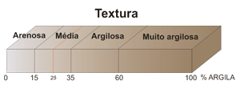

```r
dados %>%
  mutate(
    TEXTURA = case_when(
        ARGILA < 15 ~ "Arenosa",
        ARGILA <= 35 ~ "Media",
        ARGILA <= 60 ~ "Argilosa",
        ARGILA > 60 ~ "Muito argilosa",
        TRUE ~ "Sem classificação")
  )
```

#### 10.8. summarise e group_by

Resumo/Agrega o conjunto de dados

**Exemplo 1:**. Calcule as estatísticas descritivas para alguns atributos do solo de sua preferência.

```r
dados %>%
  group_by(SUP) %>%
  summarise(N=length(Ca),
            media = mean(Ca),
            mediana =median(Ca),
            variancia = var(Ca),
            assimetria = agricolae::skewness(Ca)
  )
```

# 11. Gráficos usando o ggplot2

**Exemplo 1:**. Construa um gráfico de dispersão entre os teores de Ca e Mg.

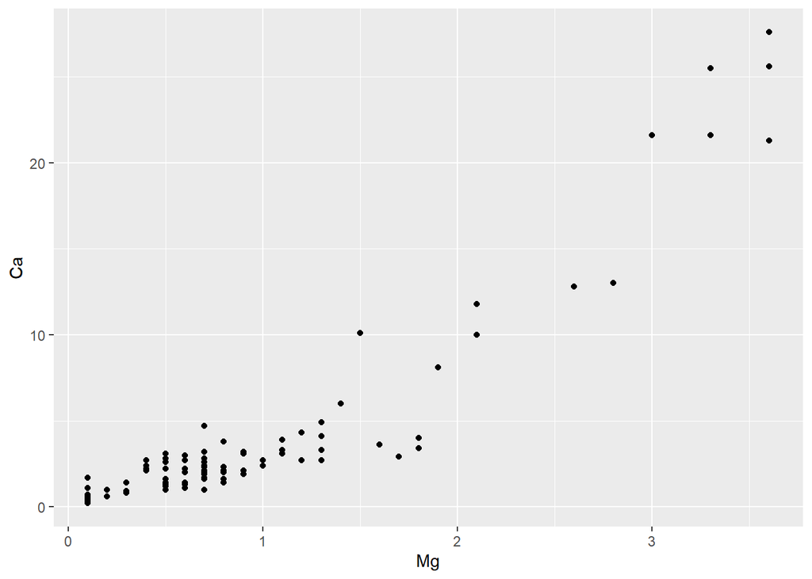

```r
# chamar os dados
# filtrar, agrupar, gerar estatísticas se necessário
# adicionar as camadas gráficas com o sinal de adição "+"

# Gráfico de Dispersão
dados %>%
  ggplot(aes(x=Mg,y=Ca) ) +
  geom_point()
```

**Exemplo 2:**. Construa um gráfico de dispersão entre a ARGILA e SILTE, mapeie as Superfícies por meio das cores no novo gráfico.

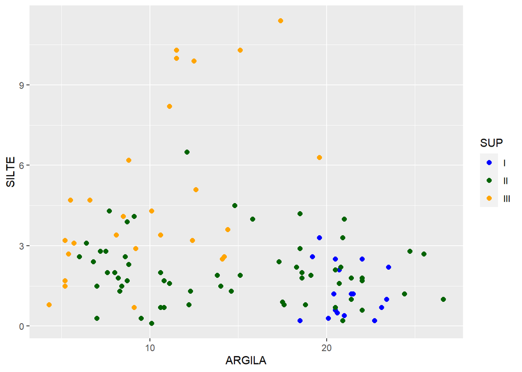

```r
dados %>%
  ggplot(aes(x=ARGILA,y=SILTE,col=SUP) ) + # dizer quem será o x e o y dentro de aes
  geom_point(size=2)+
  scale_color_manual(values=c('blue','darkgreen','orange'))
```

**Exemplo 3:**. Construa um gráfico de dispersão entre a Ca e Mg, mapeie as Superfícies por meio das formas dos marcadores no novo gráfico.

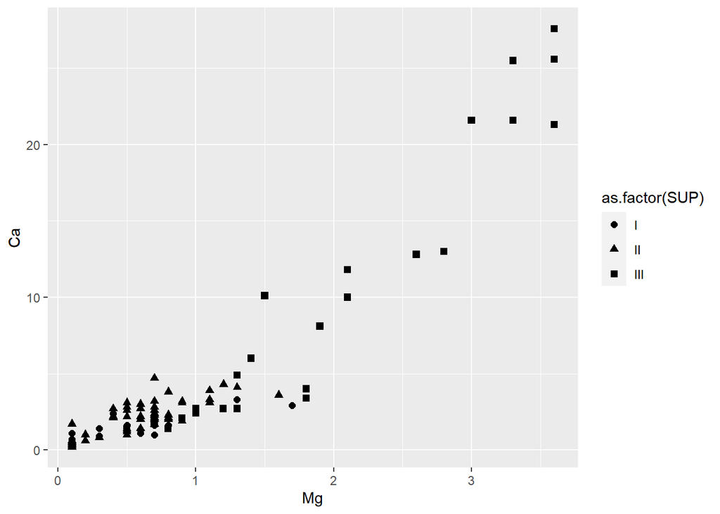

```r
dados %>%
  ggplot(aes(x=Mg,y=Ca)) +
  geom_point(aes(shape=as.factor(SUP)),size=2)
```

**Exemplo 4:**. Adicione os títulos dos gráficos, eixos e legendas.

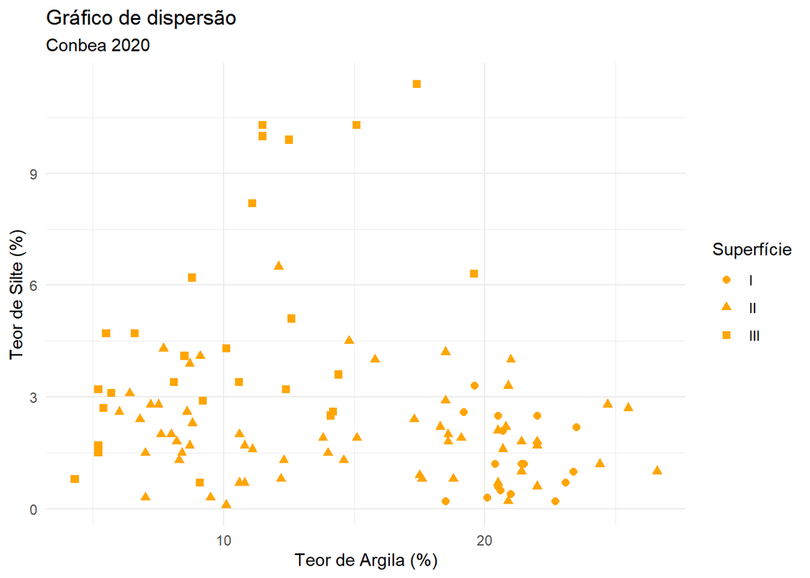

```r
dados %>%
  ggplot(aes(x=ARGILA,y=SILTE) ) + # dizer quem será o x e o y dentro de aes
  geom_point(aes(shape=as.factor(SUP)),color="orange",size=2)+
  theme_minimal()+
  labs(x="Teor de Argila (%)",y="Teor de Silte (%)",shape="Superfície") +
  ggtitle("Gráfico de dispersão",subtitle = "Conbea 2020")
```

**Exemplo 5:**. Criar um gráfico de barras, com os solos presentes na superfície “III”.

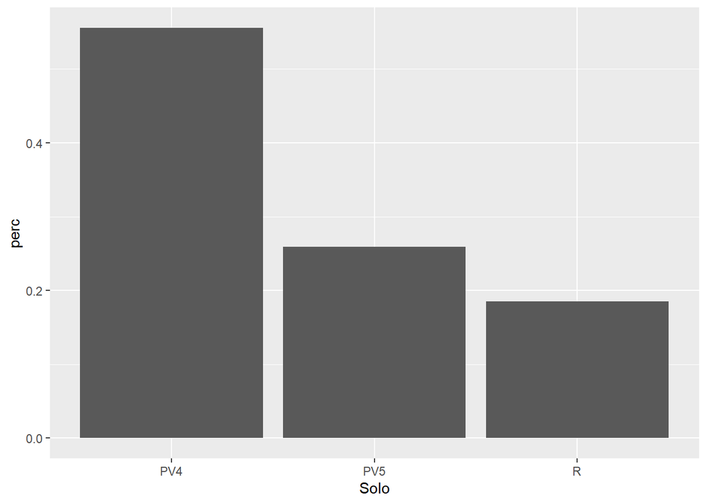

```r
dados %>%
  filter(SUP=="III") %>%
  group_by(Solo) %>%
  summarise(n=n()) %>%
  mutate(perc=n/sum(n)) %>%
  ggplot(aes(x=Solo, y=perc))+
  geom_col()
```

**Exemplo 6:**. Altere os eixos e as cores do gráfico anterior.

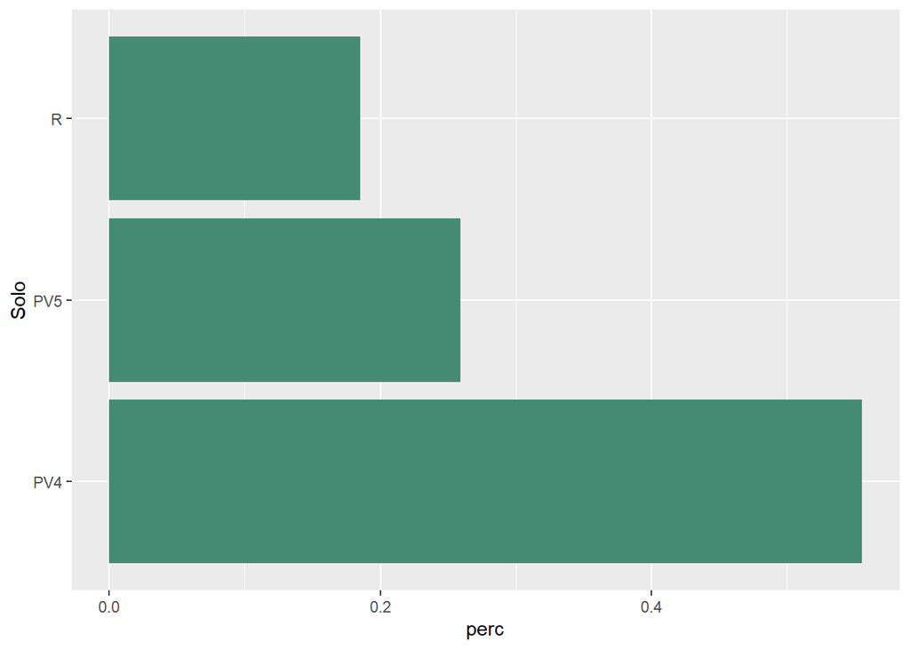

```r
# Gráfico de Barras
dados %>%
  filter(SUP=="III") %>%
  group_by(Solo) %>%
  summarise(n=n()) %>%
  mutate(perc=n/sum(n)) %>%
  ggplot(aes(x=Solo, y=perc))+
  geom_col(fill="aquamarine4") +
  coord_flip()
```

**Exemplo 7:**. Ordene o banco de dados dos Solos mais observados para os menos observados.

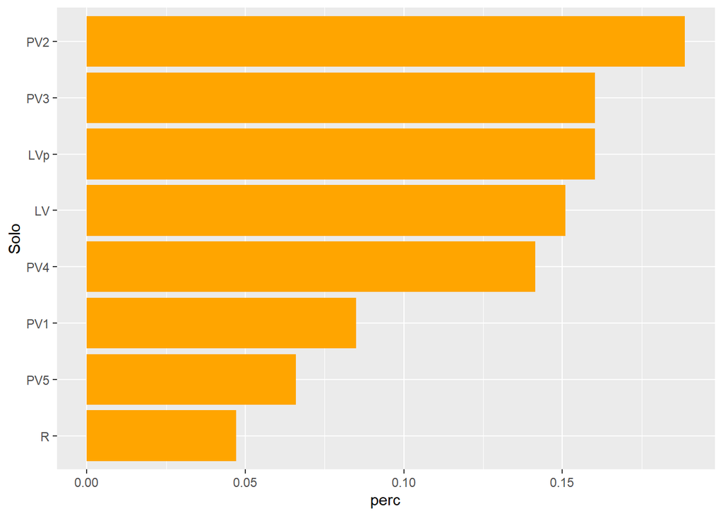

```r
# Gráfico de Barras
dados %>%
  group_by(Solo) %>%
  summarise(n=n()) %>%
  mutate(perc=n/sum(n),
         Solo = Solo %>% fct_lump(n=10,w=perc) %>% fct_reorder(perc)) %>%
  ggplot(aes(x=Solo, y=perc))+
  geom_col(fill="orange") +
  coord_flip()
```

**Exemplo 8:**. Criar o gráfico de colunas para as médias de Teor de ARGILA para cada Solo.

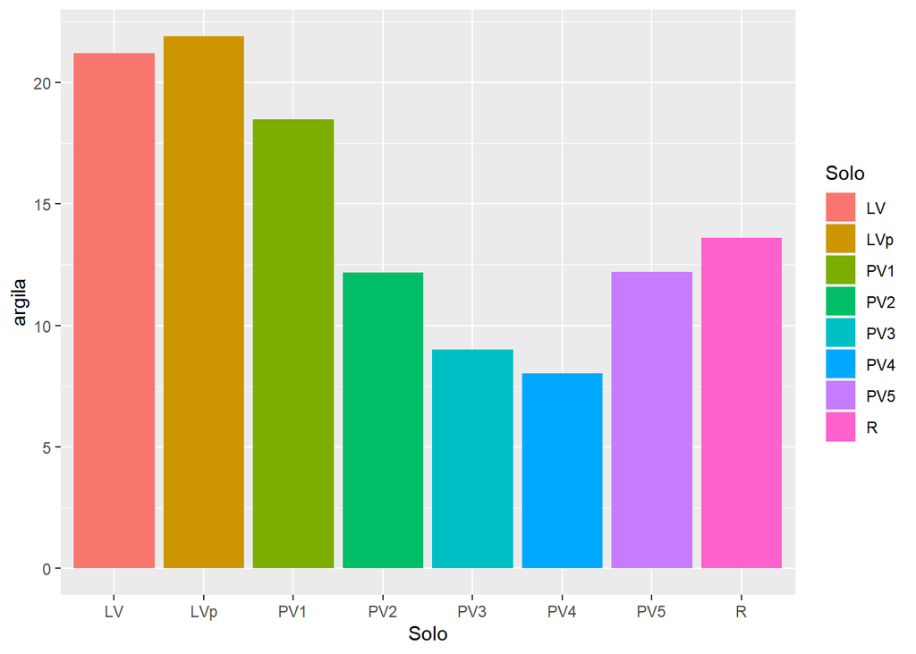

```r
dados %>%
  group_by( Solo) %>%
  summarise(argila=mean(ARGILA)) %>%
  ggplot(aes(x=Solo,y=argila,fill=as.factor(Solo))) +
  geom_col()+
  labs(fill="Solo")
```

**Exemplo 9:**. Adicione a linha de tendência linear entre Ca e Mg para cada SUP.

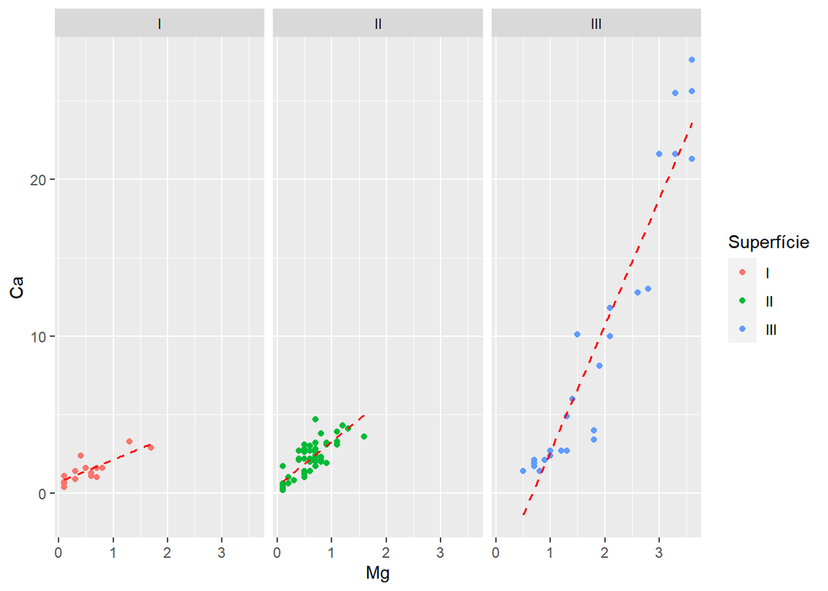

```r
# Gráfico das médias por ano em cada fazenda
dados %>%
  group_by(SUP) %>%
  ggplot(aes(x=Mg,y=Ca,color=as.factor(SUP))) +
  geom_point()+
  facet_wrap(~SUP)+  # scales = "free", se necessário
    geom_smooth(mapping = aes(x=Mg, y=Ca),
              method="lm",
              color="red",lwd=.6,lty=2,
              se=FALSE)+
  labs(col="Superfície")
```

**Exemplo 10:**. Construa o gráfico de distribuição de frequência para as variáveis contínuas do banco de dados.

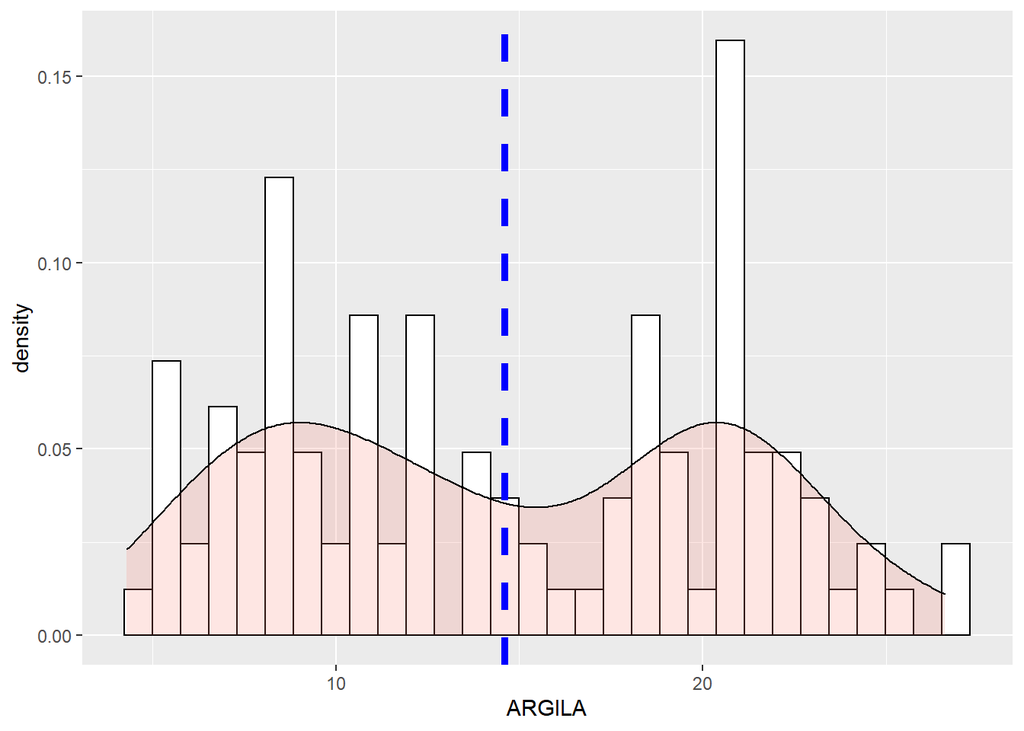

```r
# Hitograma das variáveis contínuas
dados %>%
  group_by(SUP) %>%
  ggplot(aes(x=ARGILA))+
  geom_histogram(aes(y=..density..),color="black",fill="white",bins=30)+
  geom_density(alpha=.2,fill="salmon")+
  geom_vline(aes(xintercept=mean(ARGILA)),color="blue",size=1.6,linetype="dashed")
```

**Exemplo 11:**. Construa o gráfico de distribuição de frequência para uma variável específica em cada superfície.

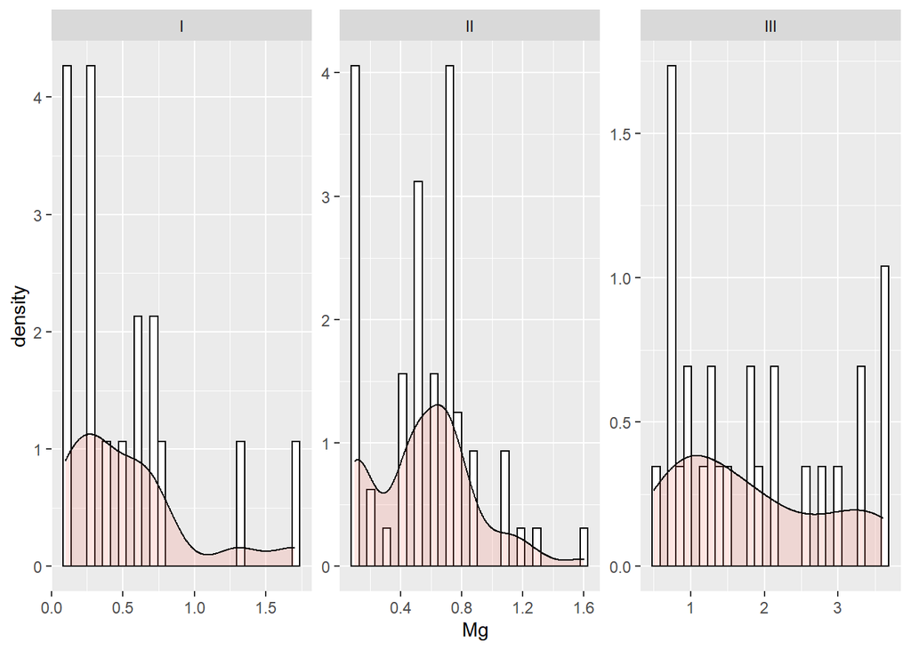

```r
dados %>%
  group_by(SUP) %>%
  ggplot(aes(x=Mg))+
  geom_histogram(aes(y=..density..),color="black",fill="white",bins=30)+
  geom_density(alpha=.2,fill="salmon")+
  facet_wrap(~SUP,scales = "free")
```

## Exemplo de Violin plot

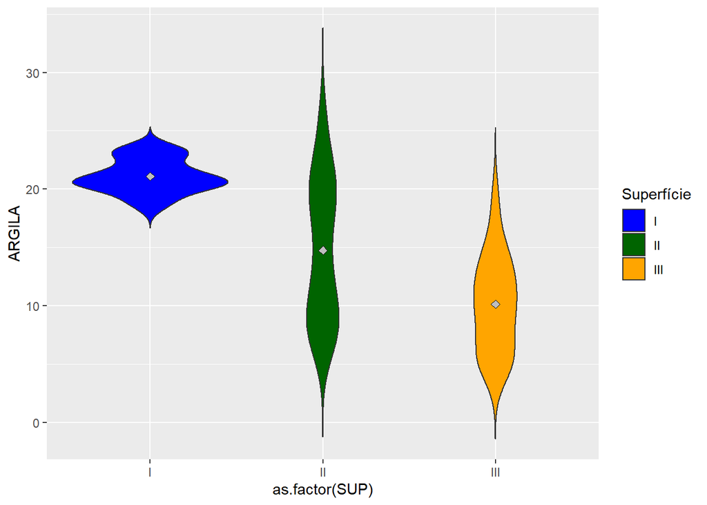

```r
dados %>%
  ggplot(aes(y=ARGILA,x=as.factor(SUP),fill=as.factor(SUP))) +
  geom_violin(trim = FALSE) +
  stat_summary(fun = mean, geom = "point",shape=23,size=2,color="black",fill="gray")+
  labs(fill="Superfície")+
  scale_fill_manual(values=c('blue','darkgreen','orange'))
```